# Flights Delay Explanatory Analysis

## by Abara Charles Ikenna

## Investigation Overview

The cleaned data had over 30 million entries. At the end of the process I was able to visualize the destribution of flight delays and explore relationships between several features. The arrival flight delay destribution showed that most flight delays are short. The different causes of delay seem to me intertwined but the analysis did not establish any direct relation amongs them. Finally, I explored the nature of arrival delays for different airports and airlines.

## Dataset Overview

- **DEPATURE_DATE** The depature date(datetime)
- **ARRIVAL_DELAY** arrival delay, in minutes: A flight is counted as "on time" if it operated less than 15 minutes later the scheduled time shown in the carriers' Computerized Reservations Systems (CRS).
- **AIRLINE** unique carrier code
- **ORIGIN_AIRPORT** ORIGIN_AIRPORT IATA airport code
- **DESTINATION_AIRPORT** DESTINATION_AIRPORTination IATA airport code
- **CARRIER_DELAY** in minutes: Carrier delay is within the control of the air carrier. Examples of occurrences that may determine carrier delay are: aircraft cleaning, aircraft damage, awaiting the arrival of connecting passengers or crew etc.
- **WEATHER_DELAY** in minutes: Weather delay is caused by extreme or hazardous weather conditions that are forecasted or manifest themselves on point of departure, enroute, or on point of arrival.
- **NAS_DELAY** in minutes: Delay that is within the control of the National Airspace System (NAS) may include: non-extreme weather conditions, airport operations, heavy traffic volume, air traffic control, etc.
- **SECURITY_DELAY** in minutes: Security delay is caused by evacuation of a terminal or concourse, re-boarding of aircraft because of security breach, inoperative screening equipment and/or long lines in excess of 29 minutes at screening areas.
- **LATE_AIRCRAFT_DELAY** in minutes: Arrival delay at an airport due to the late arrival of the same aircraft at a previous airport. The ripple effect of an earlier delay at downstream airports is referred to as delay propagation.
- **STATUS** on-time(0), delayed(1), diverted(2), cancelled(3)
- **CANCELLATION_CODE** reason for cancellation (A = carrier, B = weather, C = NAS, D = security)

## Correlation Matrix

The heatmap will show how Arrival delay correlates with `Weather Delay`, `Late Aircraft Delay`, `NAS Delay`, `Security` and `Carrier Delay`. The correlation between two features could be positive or negative.

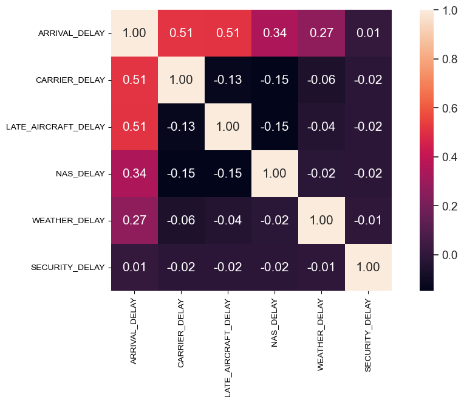

## Arrival delay by Airport

Since the dataset has over 300 airports, we will be working with the top 30 busiest airports. The horizontal barplot shows the average arrival delay for to busiest airport . NAS Delay is within the control of the National Airspace System (NAS) and may include: non-extreme weather conditions, airport operations, heavy traffic volume, air traffic control. This is why it was used for the comparrison.

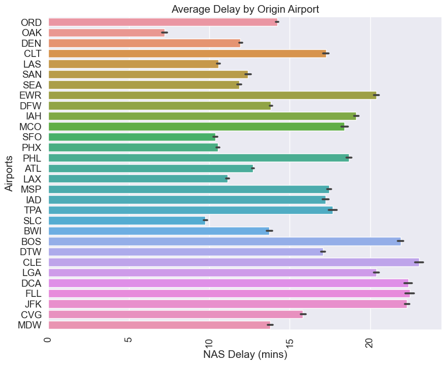

## Arival delays by Airlines

The stripplot shows all observations of arrival delay for all airlines while the barplot shows the average delay by airlines.

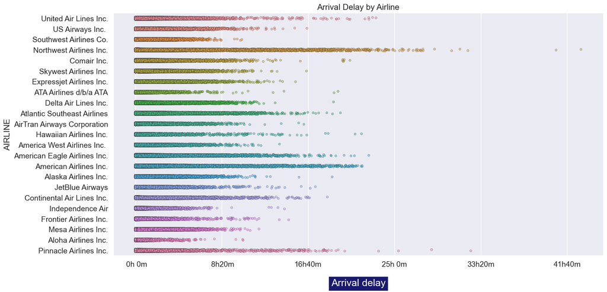

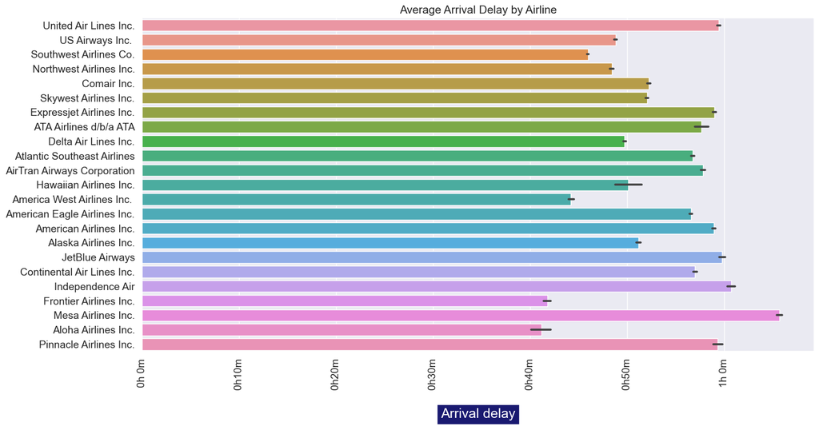

# Contribution of each delay issue to arrival delay

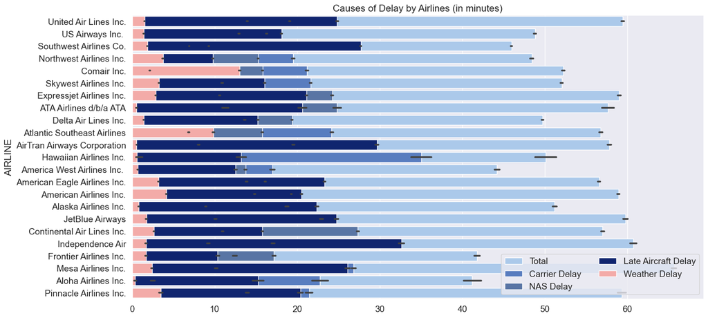